# Lecture 7：データを意思決定に使う

ターゲティング・顧客価値・コンジョイント

Kei Ikegami

## 第6回の復習

1. 母集団の割合と本人の履歴から、事後確率をどう求めるか。
2. なぜ一人の選択確率を掛けてから、タイプについて平均するか。
3. 既知のタイプの割合を推定するEMでは、Mステップで何を更新するか。

小テスト7で確認する。

## 今日の問い

第6回で、本人がどのタイプかを**確率で**表した。

その分布から、誰にクーポンを送り、将来利益をどう予測し、どんな商品を作るかを考える。

## 第6回の推定を意思決定に使う

| 知りたいこと | 比較する量 |
| --- | --- |
| クーポンを送るか | 配布あり・なしの期待利益の差 |
| 将来どれだけ利益が生まれるか | 各月の期待利益の割引合計 |
| 商品Aをどう変えるか | 候補ごとのA・B合計の期待利益 |

どれも、本人のタイプを断定せずに計算できる。

## 同じコーヒー選択モデル

$$u_{iAt}=1.5-\theta_i-p_{At}+\varepsilon_{iAt},\qquad
u_{iBt}=1.5+\theta_i-p_{Bt}+\varepsilon_{iBt}.$$

$$u_{i0t}=\varepsilon_{i0t},\qquad
\theta_i\in\{-1.5,0,1.5\}.$$

Aは苦い、Bは甘い、0は買わない。価格の単位は100円。

本人のタイプは固定。独立なGumbelショックが毎回変わる。

## タイプごとの選択確率

$v_A(\theta)=1.5-\theta-p_A$、$v_B(\theta)=1.5+\theta-p_B$ とすると、

$$P_j(\theta;p_A,p_B)
=\frac{\exp\{v_j(\theta)\}}
{1+\exp\{v_A(\theta)\}+\exp\{v_B(\theta)\}},\quad j=A,B.$$

「買わない」の分子は1である。

同じ価格でも、タイプによってA・B・非購入の確率が違う。

## 購入しなかった機会も履歴に含める

一人6回の選択機会で、選択とA・Bの提示価格を記録する。

価格は250円・300円・350円から独立に無作為化する。

$$H_i=\{(y_{it},p_{At},p_{Bt}):t=1,\ldots,6\},
\qquad y_{it}\in\{0,A,B\}.$$

購入した行だけでは、今回のモデルに必要な履歴が揃わない。

## 一人の確率を掛けてから、タイプを足す

$$L_{ik}=\prod_{t=1}^{6}P_{y_{it}}(\vartheta_k;p_{At},p_{Bt}),\qquad
\ell(\pi)=\sum_i\log\left(\sum_k\pi_kL_{ik}\right).$$

$$\widehat w_{ik}
=\frac{\widehat\pi_kL_{ik}}{\sum_\ell\widehat\pi_\ell L_{i\ell}}.$$

$\widehat w_{ik}$ は、履歴を見た後で本人がタイプ $k$ である確率。

## 母集団の割合と、本人の分布

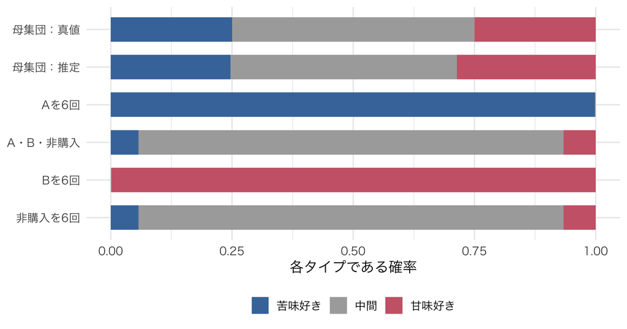

例はA・Bとも300円の6機会。同じ母集団からでも事後確率は変わる。

## 本人の分布で選択確率を平均する

将来提示する価格を $p$ とすると、

$$\widehat P_{ij}(p\mid H_i)
=\sum_k\widehat w_{ik}P_j(\vartheta_k;p).$$

タイプの平均 $\widehat\theta_i=\sum_k\widehat w_{ik}\vartheta_k$ を一つだけ入れる計算とは、一般に一致しない。

logitの確率は、タイプに対して非線形だからである。

## 1．Aの50円引きクーポン

A・Bとも通常300円。原価はAが50円、Bが100円。

Aのクーポンを送ると、Aの価格は250円になる。

| 配布 $a$ | Aの購入利益 | Bの購入利益 | 送付費 |
| --- | --- | --- | --- |
| なし：0 | 250円 | 200円 | 0円 |
| あり：1 | 200円 | 200円 | 2円 |

送付費は買わなくても発生する。A・Bはどちらも自社商品。

## 購買確率を利益に換算する

タイプ $k$ にクーポンを配る条件を $a$ とすると、

$$r_k(a)=\sum_{j=A,B}100\{p_j(a)-c_j\}
P_j(\vartheta_k;p(a))-2a.$$

本人の期待利益は、タイプ別の利益を事後確率で平均した

$$\widehat r_i(a)=\sum_k\widehat w_{ik}r_k(a).$$

## よく買うタイプへの配布が有利とは限らない

| タイプ | 配布なし利益（円） | 配布による増分（円） |
| --- | --- | --- |
| 苦味好き | 126.82 | -2.94 |
| 中間 | 69.43 | 2.87 |
| 甘味好き | 103.64 | -1.70 |

苦味好きは基準利益が高いが、値引きによる利益減も大きい。

この設定で増分が正になるのは、中間のタイプである。

## 事後確率から配布を決める

$$\widehat\Delta_i
=\sum_k\widehat w_{ik}\{r_k(1)-r_k(0)\},\qquad
\widehat a(H_i)=\mathbf1\{\widehat\Delta_i>0\}.$$

予算制約がなく、他の顧客への影響もない場合のルールである。

使うのは観測履歴から得た $\widehat w_{ik}$。真のタイプは使わない。

## モデルの比較を、独立した実験で確かめる

1,200人の履歴から母集団割合を推定する。

別の6,000人の施策前履歴でルールを固定し、確率 $e=1/2$ でクーポンを無作為に送る。

観測利益 $R_i$ は、その人が実際に受けた条件での利益である。

## 割付確率で重み付けした評価

固定したルール $a(H_i)$ の、配布なしに対する増分は、

$$\widehat G(a)=\frac1N\sum_i a(H_i)
\left\{\frac{D_iR_i}{e}-\frac{(1-D_i)R_i}{1-e}\right\}.$$

各人の中括弧を含む項を $Z_i$ と置き、

$$\operatorname{SE}\{\widehat G(a)\}=s_Z/\sqrt N.$$

## 配布ルールの実験評価

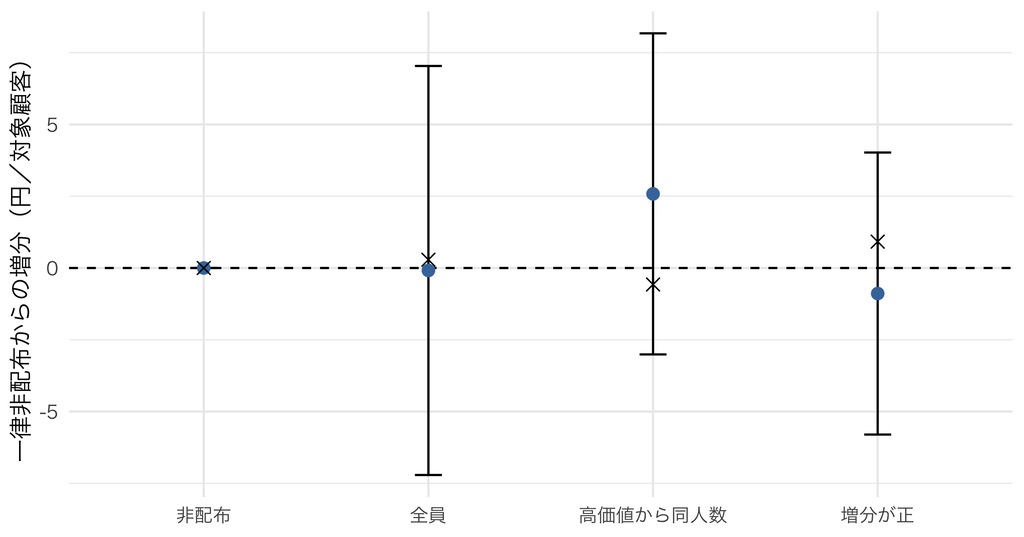

点は実験での増分、線は近似95%信頼区間。×は生成モデルの基準。

## モデルによる比較と、実験による評価

モデルでは、好み・価格・選択の関係を使って配布先を決めた。

実験では、固定した配布ルールの平均利益を確かめた。

価格係数やタイプの仮定が誤っていれば、予測した増分も変わる。

試していない施策への外挿には、さらに仮定が要る。

## 2．同じ顧客の6か月の価値

今度はクーポンなし、A・Bとも300円を続ける。

毎月1回の選択機会があり、好みと原価も変わらないとする。

その条件で、今後6か月にどれくらい利益が生まれるか。

**同じ選択モデルと、同じ本人の事後確率を使う。**

## 選択確率から顧客価値を計算する

月 $h$ の実現粗利益を $M_{ih}$、割引係数を $\delta$ とすると、

$$V_i(H)=E\left[\left.\sum_{h=1}^{H}\delta^hM_{ih}\right|H_i\right].$$

今回は毎月同じ条件なので、

$$\widehat V_i(6)=\left(\sum_{h=1}^{6}0.99^h\right)
\sum_k\widehat w_{ik}r_k(0).$$

## 好みの分布を固定して、将来を予測する

予測時点では、6回の履歴から得た $\widehat w_{ik}$ を固定する。

各月のショックは新しく引くが、本人のタイプは6か月を通じて同じ。

本人の実現利益が予測値に一致するとは限らない。

## 6か月価値の予測と実績

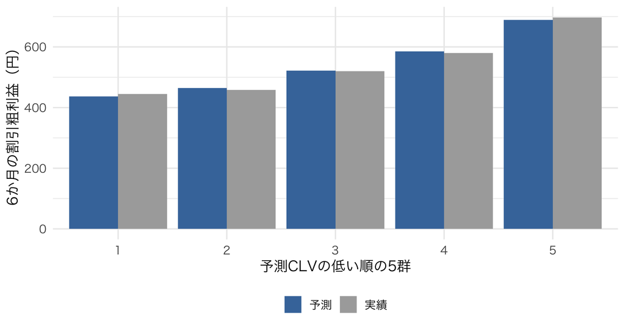

予測時点で作った群の平均を比較する。将来の実績は推定に使わない。

## CLVの高さと施策の増分

CLVが高い人は、現状のままでも利益をもたらす人である。

維持施策を選ぶには、費用込みの将来利益の差

$$E[G_i(1)-G_i(0)\mid H_i]-c_i$$

が必要になる。$G_i(a)$ は送付費等の $c_i$ を除く将来利益。

今回の1回だけのクーポン効果を、6か月続く効果とは扱わない。

## 将来の予測と、本人の先読み

ここまでの顧客は、各回の効用を比べて商品を選ぶ。

来月の値下げを待つ、買いだめして将来の購入を減らす、といった行動は入っていない。

第9回では、選択する本人が将来を考えるモデルへ進む。

## 3．商品Aの甘さと価格を変える

既存履歴では、苦いAと甘いBの組合せが固定されていた。

モデルでは中間の甘さも予測できる。調査では、甘さと価格を独立に変え、その反応を確かめる。

これが、今回の**選択型コンジョイント**である。

## 甘さと価格を無作為化した調査

| 項目 | 提示する水準 |
| --- | --- |
| A・Bそれぞれの甘さ $x_j$ | 苦い $-1$、中間 $0$、甘い $1$ |
| A・Bそれぞれの価格 $p_j$ | 250円、300円、350円 |
| 回答 | A、B、買わない |

別の回答者600人に、各8問を提示する。

最初の6問で学び、後の2問で選択確率を検証する。

## 同じ甘さの選好を、属性の変化に結びつける

$$u_{ijt}=1.5+\theta_i x_{jt}-p_{jt}+\varepsilon_{ijt},
\qquad j=A,B.$$

$$\theta_i\in\{-1.5,0,1.5\},\qquad u_{i0t}=\varepsilon_{i0t}.$$

既存商品の $x_A=-1,x_B=1$ を固定していたモデルを使う。

今回は甘さと価格の組合せを、調査側で変える。

## 回答者ごとの尤度と事後確率

$$L_{ik}^{\rm survey}=\prod_{t=1}^{6}
P_{y_{it}}(\vartheta_k;x_{At},x_{Bt},p_{At},p_{Bt}).$$

この尤度から、調査集団の割合 $\widehat\pi_k^{\rm survey}$ と 本人の $\widehat w_{ik}^{\rm survey}$ を求める。

既知のタイプ候補値・定数・価格係数という簡略化は、ここでも同じ。

## 調査から学んだタイプの割合

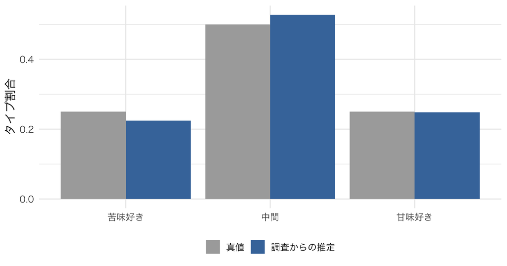

調査集団の割合を推定し、その人の回答で個人別の分布に更新する。

## 残しておいた回答で予測を確かめる

学習に使わなかった課題の属性・価格を入れて、

$$\widehat P_{ij}^{\rm test}
=\sum_k\widehat w_{ik}^{\rm survey}
P_j(\vartheta_k;x_A,x_B,p_A,p_B).$$

| 予測方法 | 後の2問の対数損失（小さいほどよい） |
| --- | --- |
| 母集団の割合だけ | 0.849 |
| 本人の6回答も使う | 0.817 |

## 商品設計で比べる候補

自社のBは、甘い・300円のまま販売する。

Aの甘さを $\{-1,0,1\}$、価格を $\{250,300,350\}$ 円から選ぶ。

Aの原価は50円、Bの原価は100円で固定する。

基準は、苦いA・300円と甘いB・300円の組合せ。

## A・Bの合計利益で候補を比べる

候補 $z=(x_A,p_A)$ に対して、

$$\widehat\Pi(z)=\frac1N\sum_i\sum_k\widehat w_{ik}^{\rm survey}
\sum_{j=A,B}100\{p_j(z)-c_j\}
P_j(\vartheta_k;z).$$

比較するのは $\widehat\Pi(z)-\widehat\Pi(z_0)$。

Aの販売増が、Bからの乗り換えによる場合も数える。

## 候補ごとの合計利益の比較

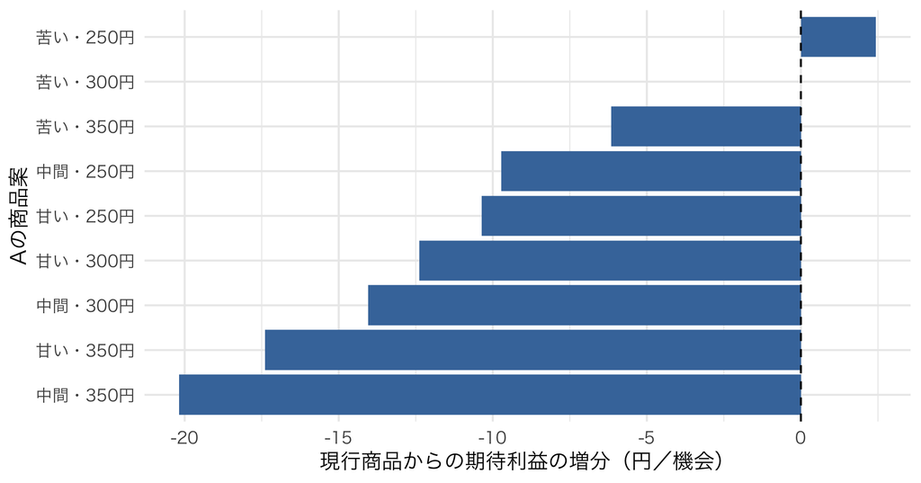

9候補を同じ条件で比較する。点・棒はモデルに基づく予測である。

## Aのシェアだけでは、商品を決められない

値下げするとAの選択確率は上がっても、一杯あたり利益は下がる。

甘さを変えると、BからAへ移る顧客もいる。

**選択確率と原価を合わせ、A・Bの利益合計で判断する。**

## AMCE・WTP・利益は違う問い

| 量 | この講義での意味 |
| --- | --- |
| AMCE | 他属性を調査設計に従って平均した選択確率の変化 |
| WTP | タイプごとの甘さ変更 $\Delta x$ に対する $100\theta_i\Delta x$ 円 |
| 期待利益 | 選択確率に各商品の利益を掛けて合計した量 |

平均的な属性効果だけでは、各人の反応や最良の商品は決まらない。

## 新しい属性には、その属性のデータが要る

今回は、既にモデル化した「甘さ」の水準を変えた。

産地表示や容量を追加するなら、それぞれへの選好を表す係数が必要になる。

甘さの好み $\theta_i$ だけから、産地表示への反応は分からない。

追加属性を調査で変え、その反応を学ぶ設計が必要である。

## 今日のまとめ

- 本人のタイプの分布から、条件ごとの選択確率を平均する。
- クーポンは、費用を含む利益の差で配布を決める。
- 同じ選択確率を将来に使い、割引合計でCLVを計算する。
- コンジョイントは、属性を変えた選択を学ぶために設計する。
- 予測や配布ルールは、学習に使わなかった結果で検証する。

## 復習と、この先の講義

講義ノート7と課題7で、事後確率から利益までを計算する。

第8回は実務のゲスト講義。

第9回では、選択する本人が将来を考える動学的離散選択モデルへ進む。